# Demo of repdoc

**Last updated:** 2018-03-14

**repdoc checks:** (Click a bullet for more information)

- **✔** **R Markdown file:** up-to-date**

  Great! Since the R Markdown file has been committed to the Git repository, you know the exact version of the code that produced these results.
- **✔** **Environment:** empty**

  Great job! The global environment was empty. Objects defined in the global environment can affect the analysis in your R Markdown file in unknown ways. For reproduciblity it’s best to always run the code in an empty environment.
- **✔** **Seed:** `set.seed(3)`**

  The command `set.seed(3)` was run prior to running the code in the R Markdown file. Setting a seed ensures that any results that rely on randomness, e.g. subsampling or permutations, are reproducible.
- **✔** **Session information:** recorded**

  Great job! Recording the operating system, R version, and package versions is critical for reproducibility.
- **✔** **Repository version:** [58d330c](https://github.com/jdblischak/repdoc/tree/58d330c1fe5ca8ad21b135f6486019ea2bd75e20)**

  Great! You are using Git for version control. Tracking code development and connecting the code version to the results is critical for reproducibility. The version displayed above was the version of the Git repository at the time these results were generated.  
  Note that you need to be careful to ensure that all relevant files for the analysis have been committed to Git prior to generating the results (you can use `wflow_publish` or `wflow_commit`). repdoc only checks the R Markdown file, but you know if there are other scripts or data files that it depends on. Below is the status of the Git repository when the results were generated:

  ```
  Staged changes:
      Modified:   DESCRIPTION
  ```

  Note that any generated files, e.g. HTML, png, CSS, etc., are not included in this status report because it is ok for generated content to have uncommitted changes.

**Expand here to see past versions:**

| File | Version | Author | Date | Message |
| --- | --- | --- | --- | --- |
| html | [d0b6616](https://htmlpreview.github.io/?https://github.com/jdblischak/repdoc/blob/d0b661616455648a5705dc6efe061659b5fedfb5/ex1-single-file/single.html) | John Blischak | 2018-03-14 | Rebuild HTML with repdoc 0.0.0.9004. |
| html | [5caf7a1](https://htmlpreview.github.io/?https://github.com/jdblischak/repdoc/blob/5caf7a1bef6ada0857d485c1bb2668f7c765233b/ex1-single-file/single.html) | John Blischak | 2018-03-13 | Rebuild examples. |
| html | [845fbef](https://htmlpreview.github.io/?https://github.com/jdblischak/repdoc/blob/845fbef85c8df7f1983fc9eab4cf5eae402a00dd/ex1-single-file/single.html) | John Blischak | 2018-03-13 | Rebuild examples. |
| Rmd | [6a766a3](https://github.com/jdblischak/repdoc/blob/6a766a3bf2be5a961b3d675a7522d970eb0c19e3/ex1-single-file/single.Rmd) | John Blischak | 2018-03-13 | Include multiple plots in a chunk. |
| html | [002221c](https://htmlpreview.github.io/?https://github.com/jdblischak/repdoc/blob/002221c0b66d8334c549bebbccb32a29def9fc4d/ex1-single-file/single.html) | John Blischak | 2018-03-08 | Rebuild HTML with version 0.0.0.9001. |
| html | [ca7b921](https://htmlpreview.github.io/?https://github.com/jdblischak/repdoc/blob/ca7b9212c5bfdd62e225bac39278e1283e99ae42/ex1-single-file/single.html) | John Blischak | 2018-03-06 | Update examples with latest version of report. |
| html | [e56de54](https://htmlpreview.github.io/?https://github.com/jdblischak/repdoc/blob/e56de5484211b24f0ef33bbb1c66541cfa1bb4de/ex1-single-file/single.html) | John Blischak | 2018-03-01 | Update HTML files. |
| html | [a3708a1](https://htmlpreview.github.io/?https://github.com/jdblischak/repdoc/blob/a3708a15587cdb7dadaec5bdb433ea4071f3eaa2/ex1-single-file/single.html) | John Blischak | 2018-02-27 | Commit ex1 results. |
| Rmd | [8d72685](https://github.com/jdblischak/repdoc/blob/8d726857ec8e720ade98cfa94ec90387b78d5d46/ex1-single-file/single.Rmd) | John Blischak | 2018-02-27 | More documentation. |
| Rmd | [98da13c](https://github.com/jdblischak/repdoc/blob/98da13c35b51a3e466651607b7818c4430f185ba/ex1-single-file/single.Rmd) | John Blischak | 2018-02-26 | Migrate knit_root_dir control to repdoc_html. |
| Rmd | [2837d19](https://github.com/jdblischak/repdoc/blob/2837d198149972679ead1018ae12226829497435/ex1-single-file/single.Rmd) | John Blischak | 2018-02-22 | Add example of single Rmd file |

Check the working directory:

```r
getwd()
```

```
[1] "/home/jdb-work/repos/repdoc"
```

Check the seed:

```r
rpois(3, lambda = 100)
```

```
[1] 90 95 88
```

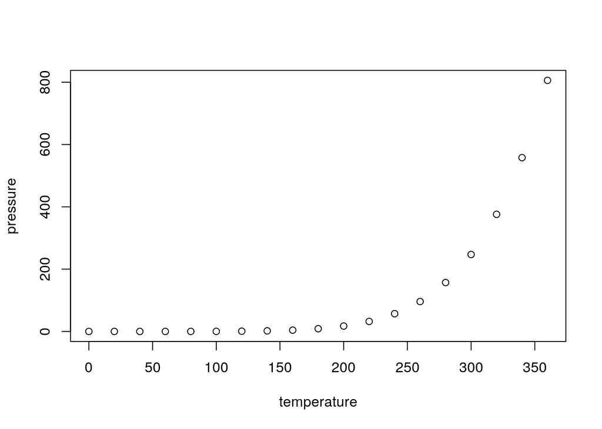

**Expand here to see past versions of pressure-1.png:**

| Version | Author | Date |
| --- | --- | --- |
| [ca7b921](https://github.com/jdblischak/repdoc/blob/ca7b9212c5bfdd62e225bac39278e1283e99ae42/ex1-single-file/figure/single.Rmd/pressure-1.png) | John Blischak | 2018-03-06 |
| [a3708a1](https://github.com/jdblischak/repdoc/blob/a3708a15587cdb7dadaec5bdb433ea4071f3eaa2/ex1-single-file/figure/single.Rmd/pressure-1.png) | John Blischak | 2018-02-27 |

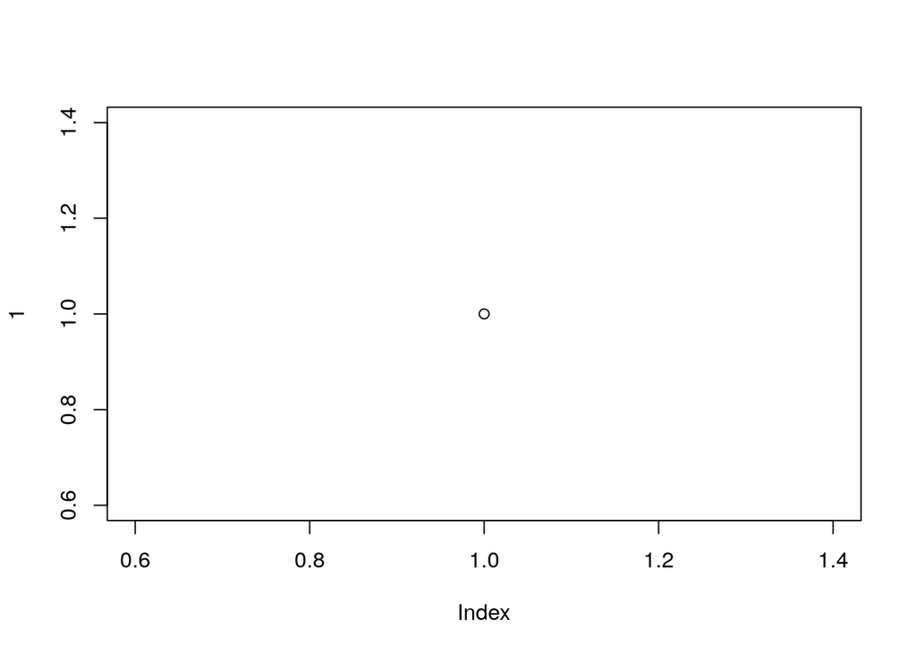

**Expand here to see past versions of pressure-2.png:**

| Version | Author | Date |
| --- | --- | --- |
| [845fbef](https://github.com/jdblischak/repdoc/blob/845fbef85c8df7f1983fc9eab4cf5eae402a00dd/ex1-single-file/figure/single.Rmd/pressure-2.png) | John Blischak | 2018-03-13 |

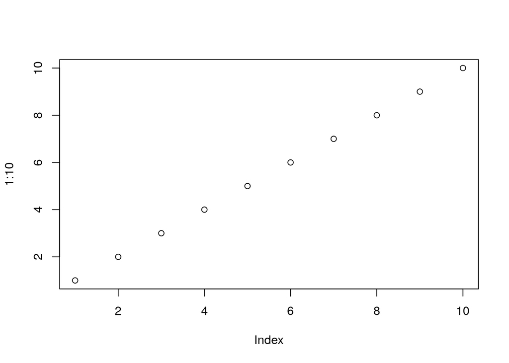

```r
plot(1:10)
```

**Expand here to see past versions of unnamed-chunk-3-1.png:**

| Version | Author | Date |
| --- | --- | --- |
| [845fbef](https://github.com/jdblischak/repdoc/blob/845fbef85c8df7f1983fc9eab4cf5eae402a00dd/ex1-single-file/figure/single.Rmd/unnamed-chunk-3-1.png) | John Blischak | 2018-03-13 |

This reproducible [R Markdown](http://rmarkdown.rstudio.com) analysis was created with repdoc 0.0.0.9004